# Bayesian Information Borrowing with Applications in Clinical Trials

2025-10-22

# 1 Introduction

本文旨在完善Bayesian统计在临床试验中应用时涉及的算法，所考虑的先验仅包括混合先验和幂先验。章节2简介混合先验及幂先验信息借用的统计学理论。章节3讨论混合先验和幂先验信息借用在SAP模板的各主要终点中的应用 (对应的频率学派方法为MMRM、ANCOVA、negative binomial regression、stratified CMH以及stratified Cox-PH regression)。章节4将基于`rstan`实现混合先验及幂先验信息借用在实际数据中的应用，通过不同场景下的模拟案例，就参数估计和假设检验，比较不同类型的先验下，频率学派方法、混合先验信息借用和幂先验信息借用的统计性能。

# 2 Method and Notation

令$D$表示分析数据，$D_{hst}$表示历史数据，$\theta$表示模型参数，$w\in [0, 1]$表示混合先验的权重参数或幂先验的温度参数。令$D=(Y, A, Z)$分别表示分析数据的结局、治疗分组和协变量，$D_{hst}=(Y_{hst}, A_{hst}, Z_{hst})$分别表示历史数据的结局、治疗分组和协变量，$1\leq i\leq n$表示第i个个体。$p_{hst}(\theta|D_{hst})$表示信息先验。

## 2.1 混合先验信息借用

混合先验将信息先验$p_{hst}(\theta|D_{hst})$和模糊先验$\pi_{vag}(\theta)$按一定的权重混合，其中，$\pi_{vag}(\theta)$通常取弱信息共轭先验（如对二分类终点，可取Jeffreys’ prior；对其他终点可取unit information prior）(Kass and Wasserman 1995; Schmidli et al. 2014)，
$$\begin{equation}
p_{mp}(\theta|w) \propto wp_{hst}(\theta|D_{hst})+(1-w)\pi_{vag}(\theta). \tag{2.1}
\end{equation}$$

若无法确定$w$的值，可将$w$也看作随机变量，此时将由数据自适应决定权重分配，然而，将$w$看作随机变量并不等同于dynamically borrowing (Yang et al. 2023)，
$$\begin{equation}
p_{mp}(\theta,w)\propto\left(wp_{hst}(\theta|D_{hst})+(1-w)\pi_{vag}(\theta)\right)\pi(w). \tag{2.2}
\end{equation}$$

除了式(2.1)和(2.2)的两种方法以外，还有 Yang et al. (2023) 提出的动态信息借用的混合先验self-adapting mixture prior (SAM prior)，同时，他们在文章中指出混合先验(2.2)的统计性能并不好：*In addition, we investigate three alternative approaches: (a) a fully Bayesian approach by assigning $w$ a uniform prior … none of these approaches perform well.* 此外，也有相关的材料指出$w\sim Unif(0, 1)$时fully Bayesian approach的推断结果与$w=0.5$相近。

## 2.2 幂先验信息借用

幂先验的表达式如下：
$$p_{pp}(\theta|w) \propto L(\theta|D_{hst})^w\pi_0(\theta).$$
从表达式不难得出，当$w=0$时，幂先验不借用历史数据$D_{hst}$；当 $w=1$时，幂先验完全借用历史数据$D_{hst}$。幂先验的一个重要性质为当$\pi_0(\theta)$为proper prior时，幂先验也是proper prior (Joseph G. Ibrahim et al. 2015)。

同样地，若无法确定$w$的值，幂先验也可将$w$也看作随机变量，此时有
$$\begin{equation}
p_{pp}(\theta,w)\propto L(\theta|D_{hst})^w\pi_0(\theta)\pi(w).\tag{2.3}
\end{equation}$$

然而，与混合先验不同的是，若不对信息先验$L(\theta|D_{hst})^w\pi_0(\theta)$标准化，该幂先验会违背Likelihood Principle (Robert 2007; Berry et al. 2010)：当历史数据相同时，对历史数据取不同的充分统计量，得到的先验分布也会不同，因而会产生不同的推断结果。因此，在将$w$看作随机变量时，需要进行如下标准化，
$$\begin{equation}
p_{npp}(\theta,w)=p_{pp}(\theta|w)\pi(w)=\frac{L(\theta|D_{hst})^w\pi_0(\theta)}{\int L(\theta|D_{hst})^w\pi_0(\theta)d\theta}\pi(w).\tag{2.4}
\end{equation}$$
经过标准化的幂先验(2.4)又称为NPP (Normalized power prior) 或MPP (Modified power prior)(Joseph G. Ibrahim et al. 2015; Banbeta et al. 2019)。对于initial prior $\pi_0(\theta)$的选择，从后验的收敛角度考虑，建议$\pi_0(\theta)$取proper prior。

NPP中的标准化项$C(w)=\int L(\theta|D_{hst})^w\pi_0(\theta)d\theta$通常没有显式表达式，因此常使用积分近似，具体的算法主要包括以下几类：

- Laplace approximation
- Monte Carlo Metropolis-Hastings (MCMH) algorithm (Liang and Jin 2013)
- Path sampling (Friel and Pettitt 2008; Ye et al. 2022)

由于$w$取值较小时，使用Laplace approximation可能会有较大偏差，本文档仅介绍后两种方法。使用MH算法从NPP相应的后验分布中抽样时，主要困难在于rejection的步骤中，比值$C(w)/C(w^\prime)$无法计算。基于MCMH算法，一种可行的方法是在MH算法中嵌入以下近似：
$$\frac{C(w)}{C(w^\prime)}=\frac{\int L(\theta|D_{hst})^w\pi_0(\theta)d\theta}{\int L(\theta|D_{hst})^{w^\prime}\pi_0(\theta)d\theta}=\int\frac{L(\theta|D_{hst})^w\pi_0(\theta)}{L(\theta|D_{hst})^{w^\prime}\pi_0(\theta)}\cdot\frac{L(\theta|D_{hst})^{w^\prime}\pi_0(\theta)}{\int L(\theta|D_{hst})^{w^\prime}\pi_0(\theta)d\theta}d\theta=\lim_{M\to\infty}\frac{1}{M}\sum_{i=1}^M\frac{L(\theta_i|D_{hst})^w}{L(\theta_i|D_{hst})^{w^\prime}}, a.s.,$$
其中$\theta_i\sim p_{pp}(\theta|w^\prime)\propto L(\theta|D_{hst})^{w^\prime}\pi_0(\theta)$。因此，我们可以通过MCMC算法抽取足够多的$\theta_i$来计算$C(w)/C(w^\prime)$。

Path sampling算法主要基于 Friel and Pettitt (2008) 的如下结果

$$\log C(w)=\int_0^wE_{p_{pp}(\theta|w^\ast)}[l(\theta|D_{hst})]dw^\ast,$$
其中$p_{pp}(\theta|w^\ast)\propto L(\theta|D_{hst})^{w^\ast}\pi_0(\theta)$。因此，通过先在$[0, 1]$区间划分$K$个网格，对于每一个网格端点$w_k$，使用MCMC算法从$p_{pp}(\theta|w_k)$分布对$\theta$抽样，可以近似$E_{p_{pp}(\theta|w_k)}[l(\theta|D_{hst})]$，最后基于网格和近似得到的期望可以近似计算$\log C(w)$。具体算法如下 (Ye et al. 2022)：

- Step 0: Choose a set of $K−1$ different numbers as knots between 0 and 1, and another knot at 1, with $K$ sufficiently large. Sort them in ascending order $(w_1, . . . , w_{K−1}, 1)$. Let $w_0 = 0$, $\Delta_1 = w_1, \Delta_i = w_i−w_{i−1} (1 < i ≤ K),\text{ and }\Delta_K = 1−w_{K−1}$. Choose $M$, the number of MCMC samples in a run when sampling from $p_{pp}(\theta|w)$. Initialize $l = 1$.
- Step 1: Generate $M$ samples from $p_{pp}(\theta|w_l)$ using an appropriate MCMC algorithm. Denote the sample as $(\theta_l^{(1)},\theta_l^{(2)},\dots,\theta_l^{(M)})$.
- Step 2: Calculate $h(w_l) = \sum^M_{j=1}l(\theta_l^{(j)}|D_{hst})/M$.
- Step 3: Calculate $\log C(w_l) ≈ \sum^l_{k=1} \Delta_k\{h(w_{k−1}) + h(w_k)\}$ (the Trapezoidal rule).
- Step 4: Increase $l$ by 1. If $l \leq n$ then repeat Steps 1 to 3.

相较于MCMH算法，path sampling在`stan`中易于实现。此外，MCMH算法在每次从proposal distribution抽样时，都要再嵌套一层MCMC抽样来计算acceptance ratio；而path sampling算法可以独立于MH算法给出所有的$\log C(w_l)$，因此计算效率远高于MCMH算法。综合考虑，尽管MCMH算法可能更加精准和稳定，本文优先使用path sampling实现NPP方法。在4中，由于$\log C(w)$在ANCOVA模型下有显式表达式，本文将比较使用精确$\log C(w)$和使用path sampling近似时的区别。

Neuenschwander, Branson, and Spiegelhalter (2009) 指出unnormalized power prior (2.3)在某些情况下不适用（如在估计rate时对$w$的选择会趋于0）。Hobbs et al. (2011) 指出NPP没有直接将历史数据和新数据间的可比性参数化，并且无论是unnormalized power prior还是NPP，往往都倾向于衰减$w$：*A problem with modified joint power priors is that they do not directly parameterize the commensurability of the historical and new data… Furthermore, Neelon and O’Malley (2010) caution against using Ibrahim–Chen and MPPs because they both tend to overattenuate the impact of the historical data, forcing the use of fairly large $\alpha_0$ (or in our case, fairly informative hyperpriors for $\alpha_0$) to deliver sufficient borrowing.* 同时，他们也给出了新的幂先验方法commensurate power prior (CPP)来解决上述问题。本文暂不考虑CPP方法的应用。

## 2.3 Remark

无论是混合先验，还是幂先验，需要明确研究中的目标参数。若冗余参数取值在历史数据和分析数据中相近，此时将冗余参数也纳入信息先验中，会导致在随机权重的模型中，赋予历史数据的权重膨胀，从而增加目标参数的估计偏差。因此，一般不建议将冗余参数也纳入信息先验，而是像 Hobbs et al. (2011) 文中通过极大似然估计等替代历史数据中的冗余参数。

# 3 Application

## 3.1 连续变量终点

### 3.1.1 ANCOVA模型

ANCOVA的模型假设如下：
$$Y_i=\alpha+\tau A_i+Z_i^T\gamma+\varepsilon_i, \varepsilon_i\sim N(0, \sigma^2).$$
也即，
$$Y\sim N(X\beta, \sigma^2I),$$
其中$X=[1, A, Z]\in\mathbb{R}^{n\times p}$，$\beta = [\alpha, \tau, \gamma^T]^T$。

对于历史数据，有$\beta\sim N(\hat{\beta},\sigma^2(X^TX)^{-1})$，其中$\sigma^2$可用无偏估计$\hat{\sigma}^2=RSS/(n-p)$代入。因此，混合先验为
$$p_{mp}(\beta|w)\sim wN(\hat{\beta},\hat\sigma^2(X^TX)^{-1})+(1-w)\pi_{vag}(\beta).$$

对于$\pi_{vag}(\beta)$的选取，可用unit information prior $\pi_{vag}(\beta)=N(\hat\beta_{hst},n\hat\sigma^2(X_{hst}^TX_{hst})^{-1})$。

幂先验为 (Joseph G. Ibrahim, Chen, and Sinha 2003)
$$p_{pp}(\beta,\sigma^2|w)\propto (\sigma^2)^{-\frac{nw}{2}}\exp\left\{-\frac{1}{2}(\sigma^2/w)^{-1}(Y_{hst}-X_{hst}\beta)^T(Y_{hst}-X_{hst}\beta)\right\}\pi_0(\theta).$$
同样使用无偏估计代入$\sigma^2$，此时幂先验可表示为
$$p_{pp}(\beta|w)\propto N\left(\hat\beta_{hst},w^{-1}\hat\sigma^2(X_{hst}^TX_{hst})^{-1}\right)\pi_0(\beta).$$
从该表达式也可看出，当温度$w$增加时，将借用更多的历史信息，而当温度$w$降低时，幂先验的密度将会趋于平坦，从而趋近无信息先验。在后续的模拟研究中，出于对后验收敛性的考虑，取幂先验的initial prior为
$$\pi_0(\beta)=\pi_{vag}(\beta)=N(\hat\beta_{hst},n\hat\sigma^2(X_{hst}^TX_{hst})^{-1}).$$

此时，若考虑$w$为随机变量，则
$$\log C(w)=const - \frac{pw}{2}\log 2\pi-\frac{w}{2}\log |\hat\sigma^2(X_{hst}^TX_{hst})^{-1})|-\frac{p}{2}\log w+\log N(\hat\beta_{hst};\hat\beta_{hst},(w^{-1}+n)\hat\sigma^2(X_{hst}^TX_{hst})^{-1}),$$
可以直接计算，在接下来的章节将用于评估path sampling算法的精确度。

# 4 Simulation Study

## 4.1 连续变量终点

对于连续变量终点，为简化问题，设定如下数据生成过程：

$$Y_{i}-Y_i^{baseline}=\alpha+(\tau+\delta I(i\in D))A_{i}+\gamma Y_{i}^{baseline}+\varepsilon_{i},\\
Y_i^{baseline}\overset{i.i.d.}{\sim}N(0, \sigma_Y^2)\\
\varepsilon_{i}\overset{i.i.d.}{\sim}N(0, \sigma^2).$$

其中，参数$\tau$为历史数据的治疗效应，$\delta$为分析数据与历史数据的效应差。历史数据和分析数据按照2:1的比例分配，其中分析数据的样本量$n=100$，治疗组和对照组的比例为$1:1$。对于参数，取$\alpha=0.5, \tau = 0.4, \gamma = 0.1, \sigma_Y = 0.5, \sigma=0.81$，此外，$\delta = -0.6, -0.4, -0.2, 0, 0.2, 0.4, 0.6$。

### 4.1.1 ANCOVA模型

ANCOVA模型的模拟研究主要考虑以下几种信息先验方法：

1. Fixed mixture prior (FMP) with $w=0.5$ and $\pi_{vag}(\beta)=N(\hat\beta_{hst},n\hat\sigma^2(X_{hst}^TX_{hst})^{-1})$;
2. Random mixture prior (RMP) with $w\sim Beta(1, 1)$ and $\pi_{vag}(\beta)=N(\hat\beta_{hst},n\hat\sigma^2(X_{hst}^TX_{hst})^{-1})$;
3. Fixed power prior (FPP) with $w=0.5$ and $\pi_0(\beta)=\pi_{vag}(\beta)$;
4. Unnormalized power prior (UPP) with $w\sim Beta(1, 1)$ and $\pi_0(\beta)=\pi_{vag}(\beta)$;
5. Normalized power prior (ANPP) with $w\sim Beta(1, 1)$ and $\pi_0(\beta)=\pi_{vag}(\beta)$ using path sampling;
6. Normalized power prior (NPP) with $w\sim Beta(1, 1)$ and $\pi_0(\beta)=\pi_{vag}(\beta)$ using exact $\log C(w)$;
7. ANCOVA with current data.

以下给出上述六种方法在一组示例模拟数据上的试运行结果（$\delta=0$，也即没有prior-data conflict），其中`beta[3]`为治疗效应，`sigma2`为残差方差$\sigma^2$，`w_eff`为权重或温度（trace plot通过比较各个chain的参数抽样分布来检查收敛性，pairs plot中若出现黄色和红色的散点则需要注意抽样的收敛性，在一些hierarchical models可能会出现以上问题，此时应通过non-centered parameterization处理模型）：

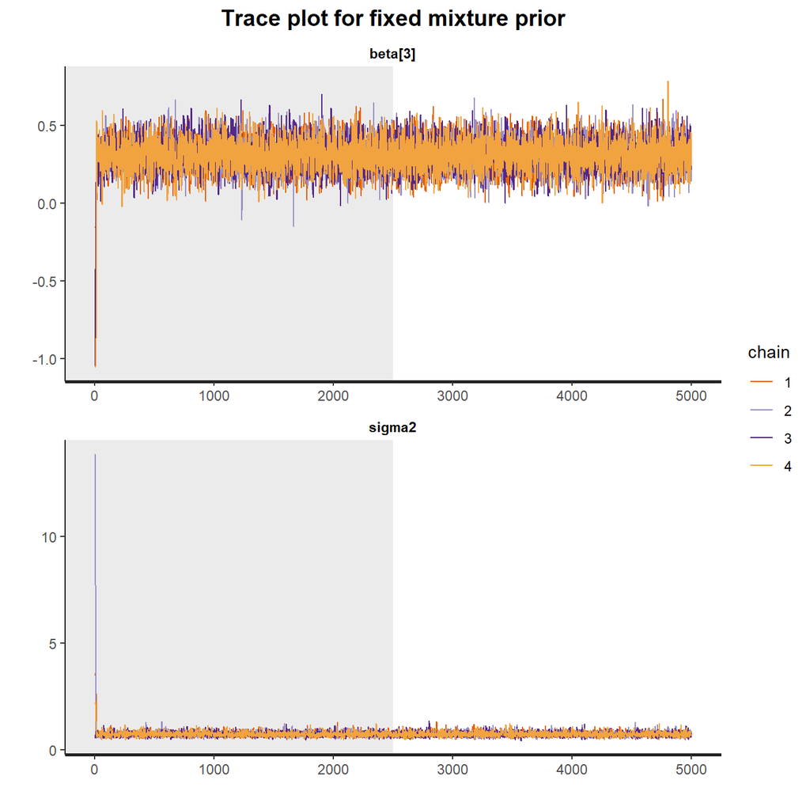

Figure 4.1: Trace plots of the posterior samples of treatment effect and residual variance under the fixed mixture prior. The shaded region marks burn-in. MCMC ran with 4 chains and 5,000 draws per chain.

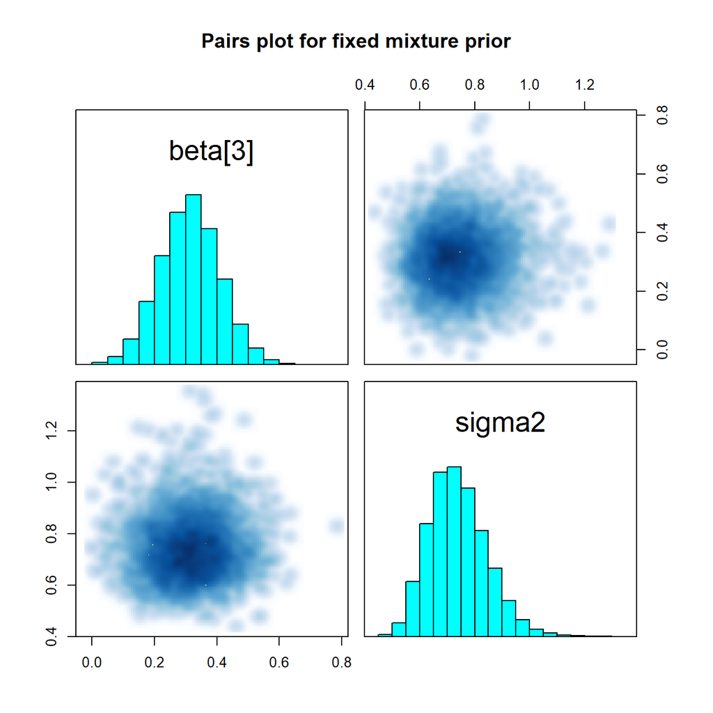

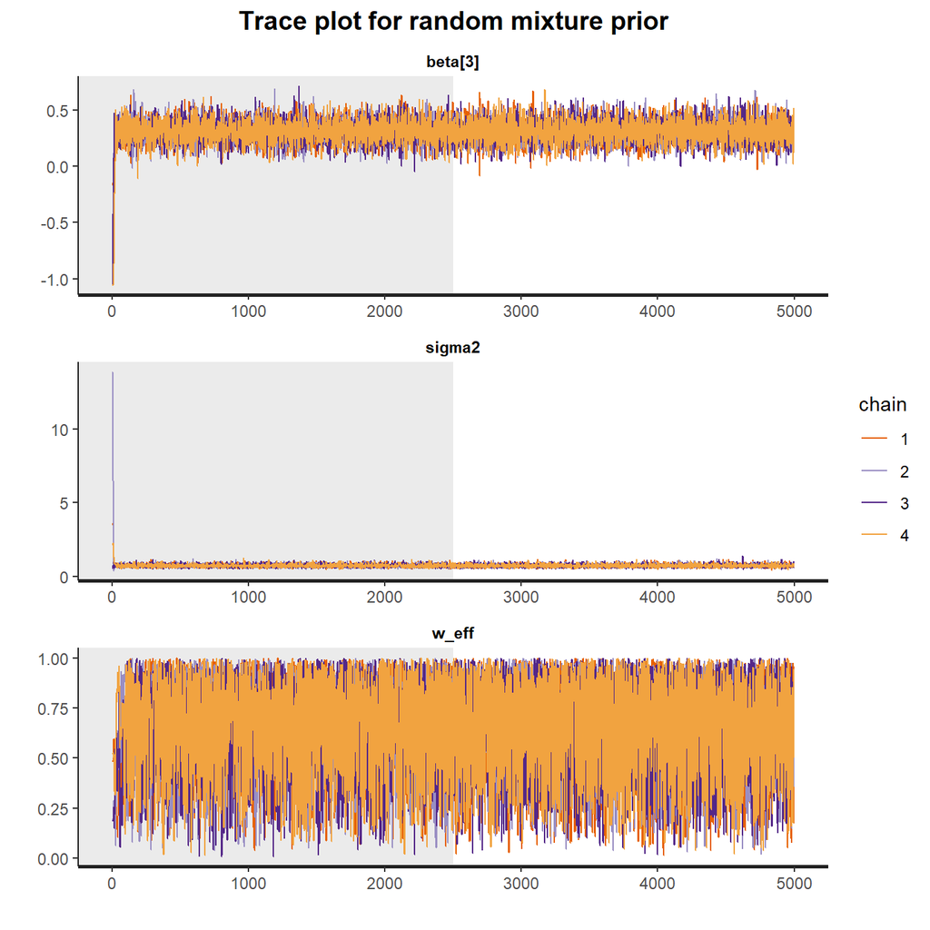

Figure 4.3: Trace plots of the posterior samples of treatment effect, residual variance, and weight under the random mixture prior. The shaded region marks burn-in. MCMC ran with 4 chains and 5,000 draws per chain.

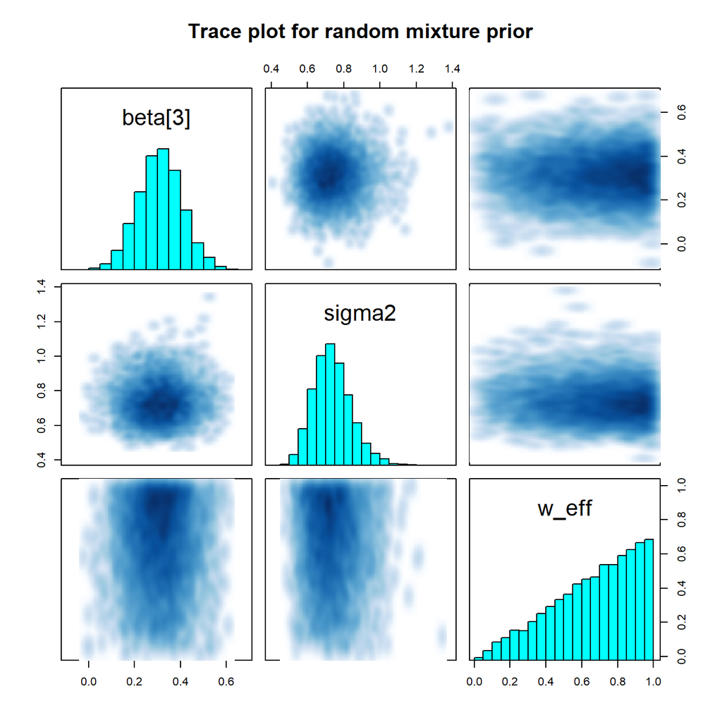

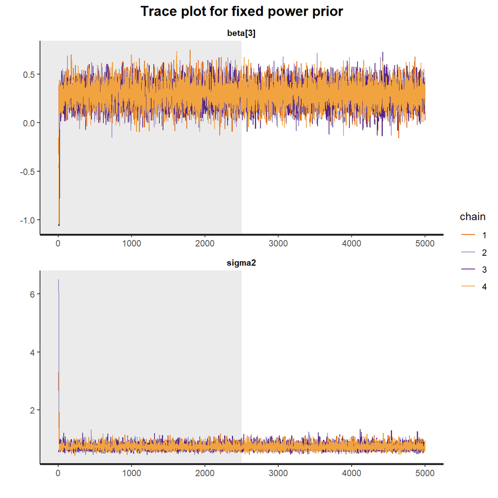

Figure 4.5: Trace plots of the posterior samples of treatment effect and residual variance under the fixed power prior. The shaded region marks burn-in. MCMC ran with 4 chains and 5,000 draws per chain.

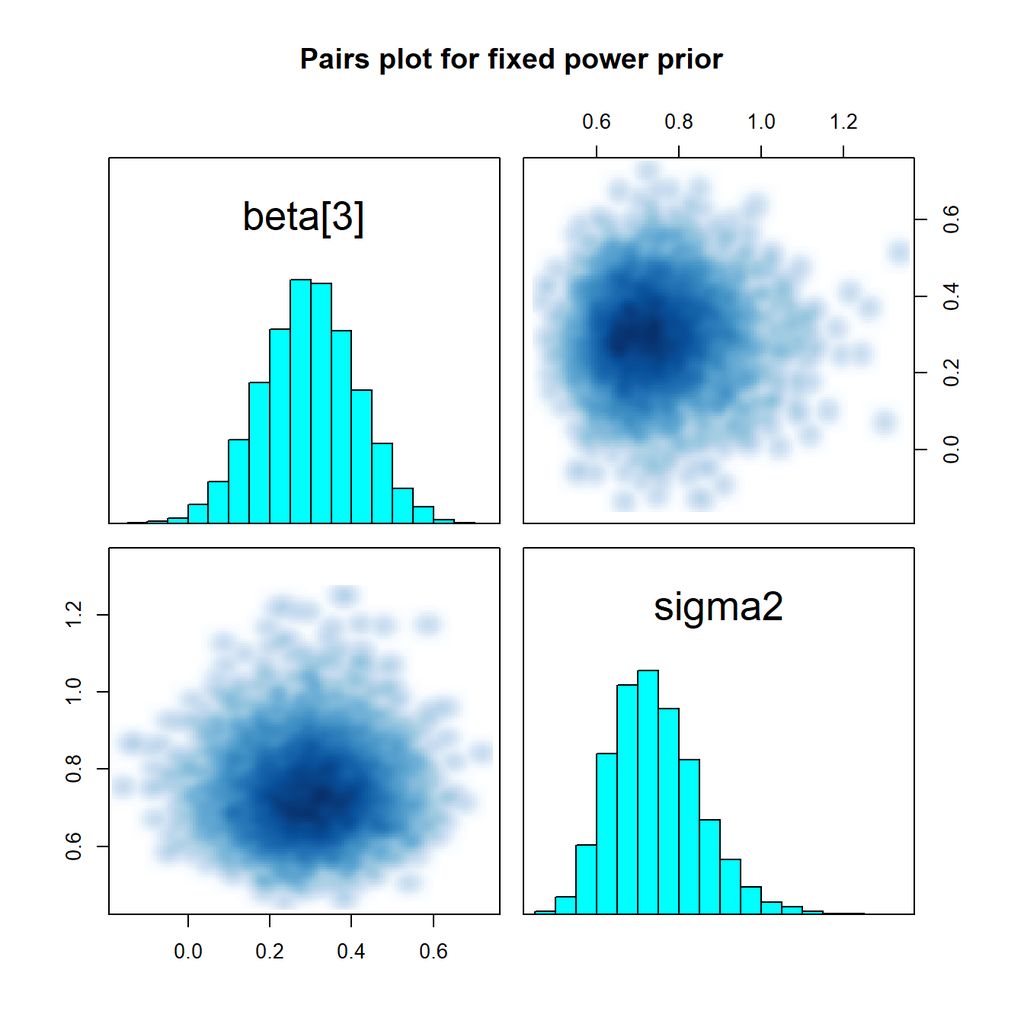

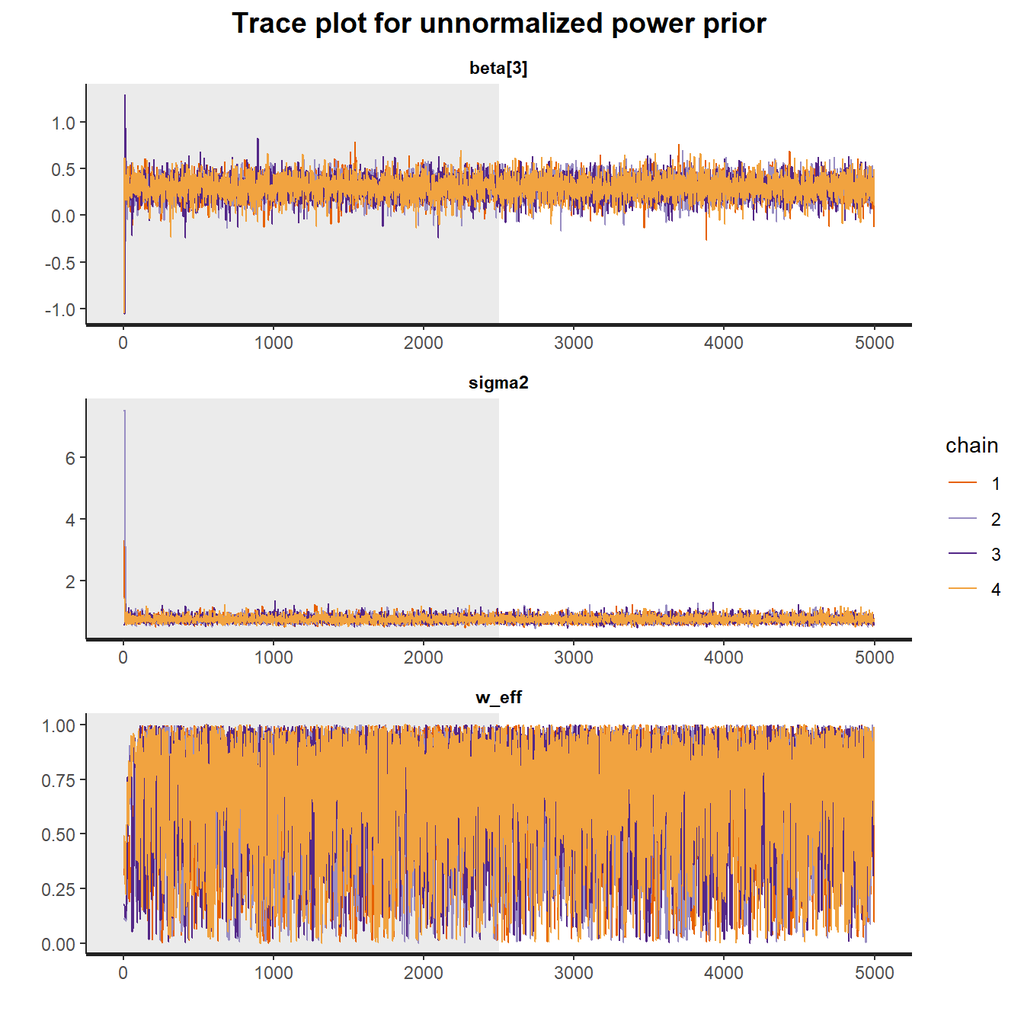

Figure 4.7: Trace plots of the posterior samples of treatment effect, residual variance, and temperature under the unnormalized power prior. The shaded region marks burn-in. MCMC ran with 4 chains and 5,000 draws per chain.

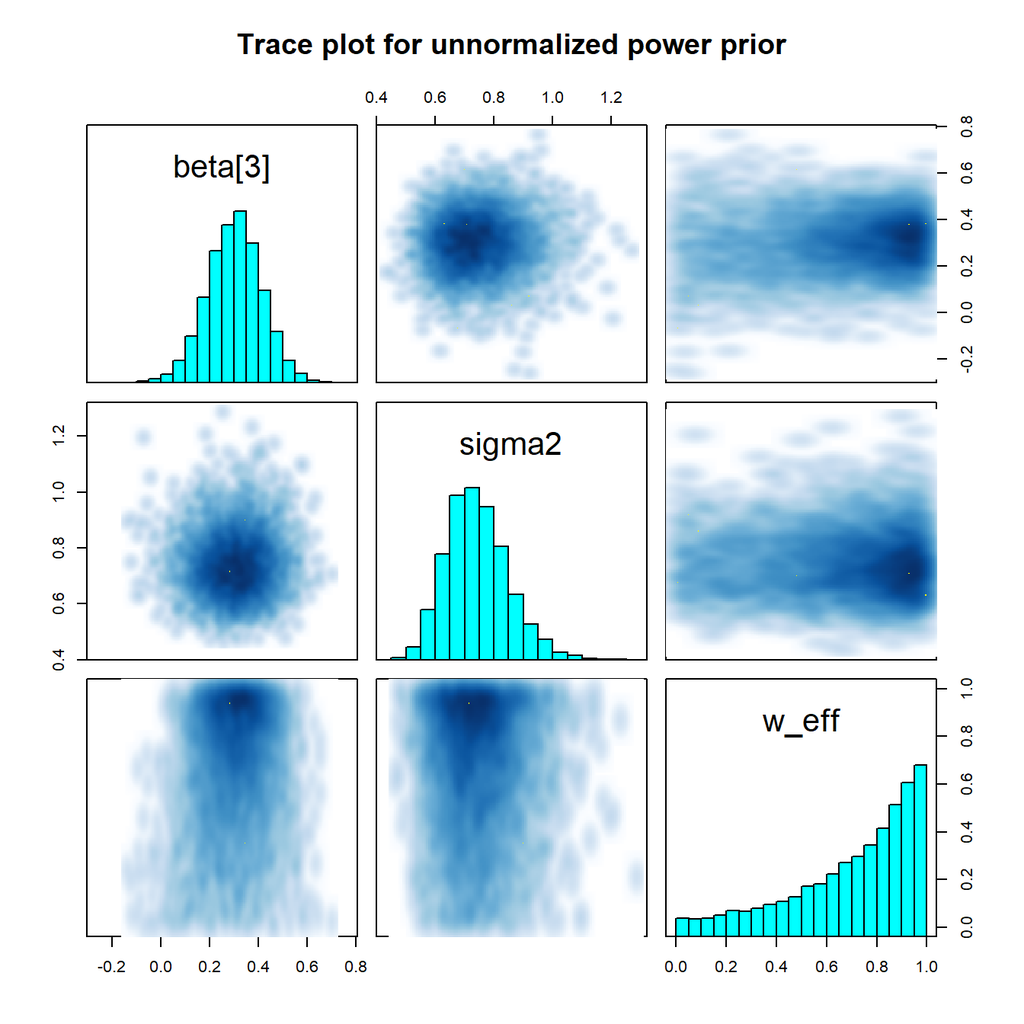

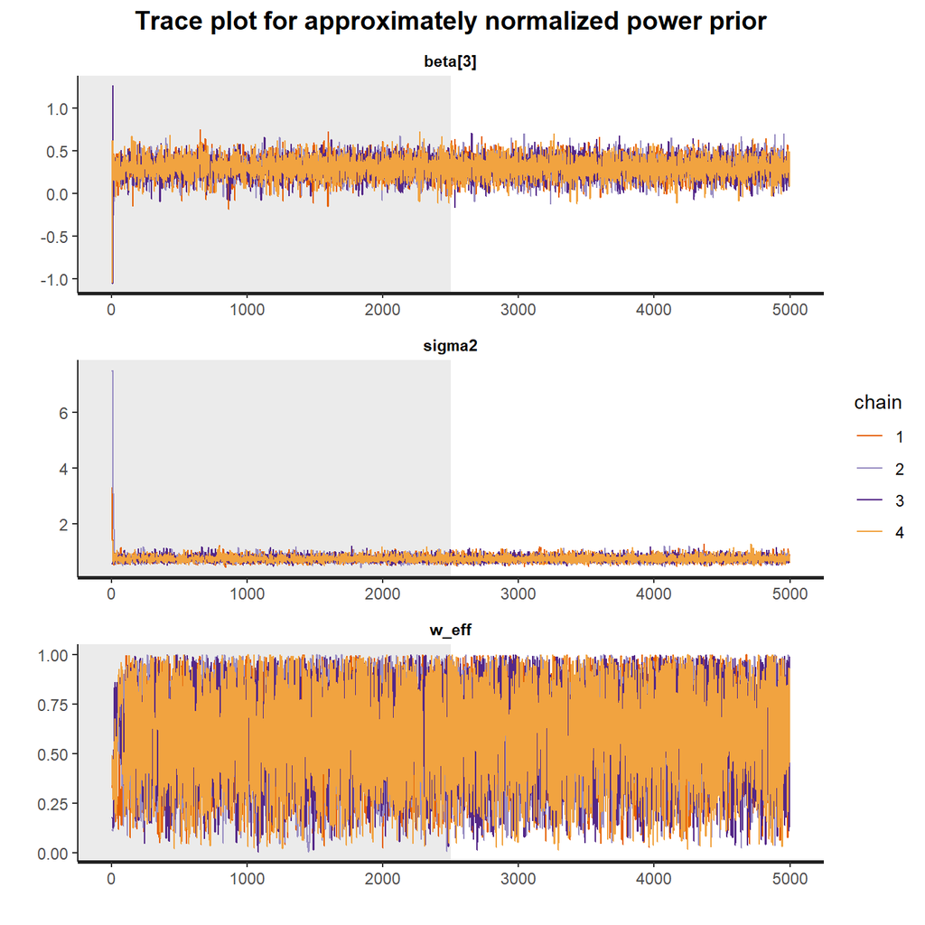

Figure 4.9: Trace plots of the posterior samples of treatment effect, residual variance, and temperature under the approximately normalized power prior using path sampling. The shaded region marks burn-in. MCMC ran with 4 chains and 5,000 draws per chain.

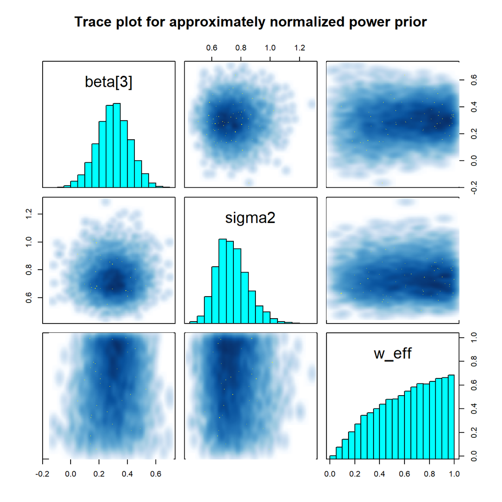

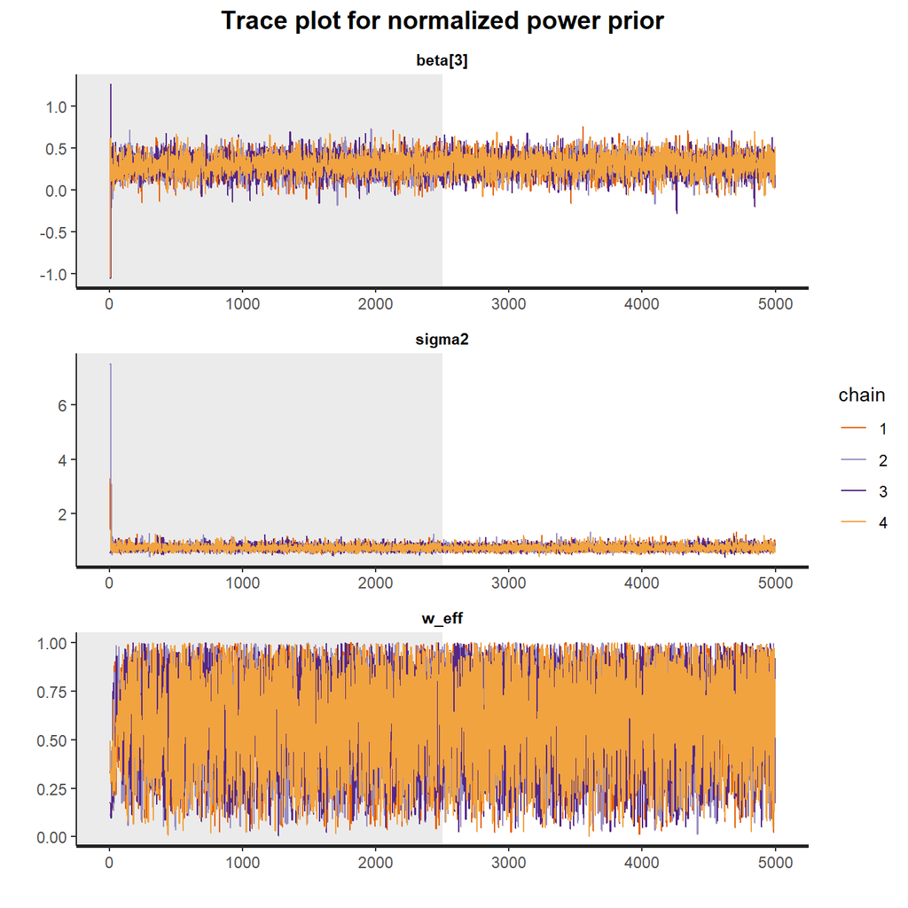

Figure 4.11: Trace plots of the posterior samples of treatment effect, residual variance, and temperature under the normalized power prior. The shaded region marks burn-in. MCMC ran with 4 chains and 5,000 draws per chain.

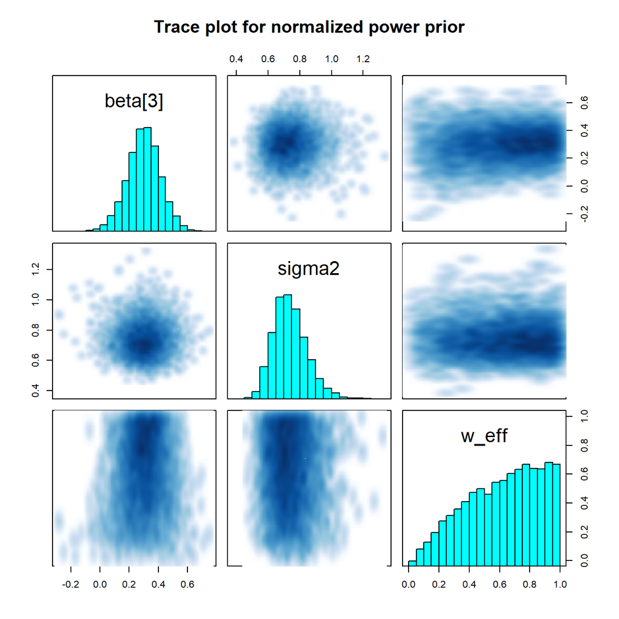

[output not shown]

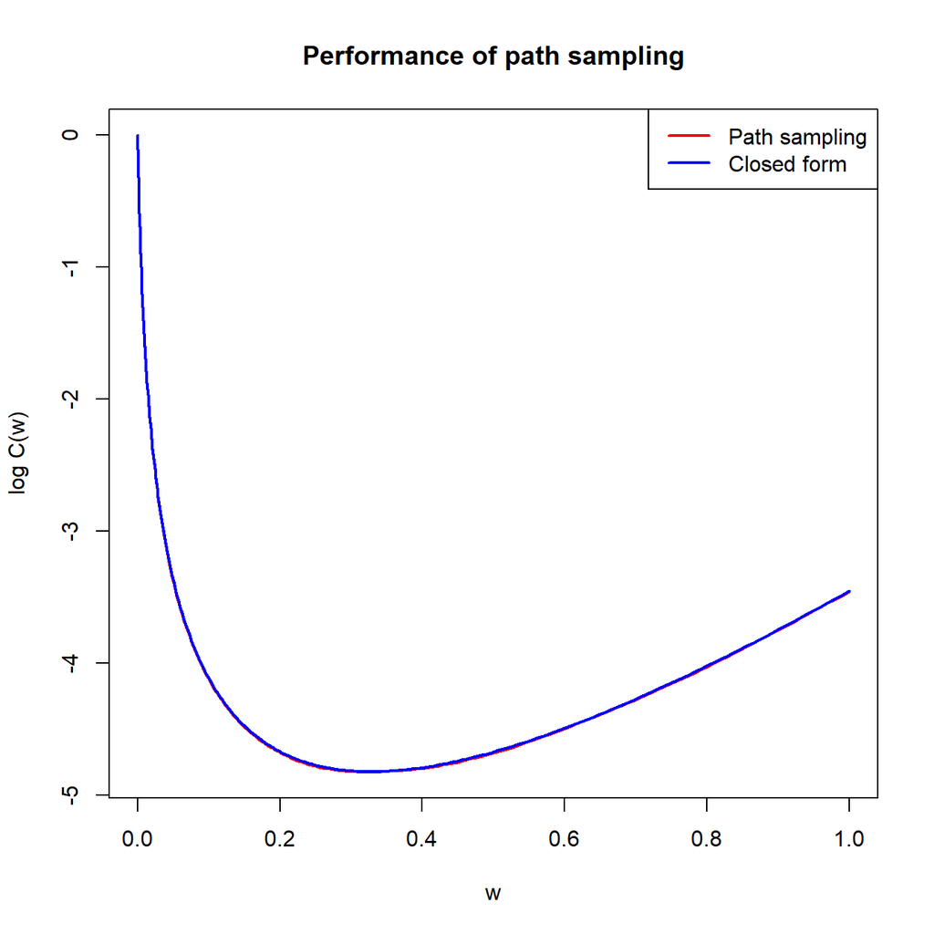

Figure 4.13: Comparison of the path sampling approximated normalization constant (red) and the closed-form normalization constant (blue).

# Reference

Banbeta, Akalu, Joost van Rosmalen, David Dejardin, and Emmanuel Lesaffre. 2019. “Modified Power Prior with Multiple Historical Trials for Binary Endpoints.” *Statistics in Medicine* 38 (7): 1147–69.

Berry, Scott M., Bradley P. Carlin, J. Jack Lee, and Peter Muller. 2010. *Bayesian Adaptive Methods for Clinical Trials*. 1st ed. Boca Raton, FL: Chapman; Hall/CRC.

Friel, N., and A. N. Pettitt. 2008. “Marginal Likelihood Estimation via Power Posteriors.” *Journal of the Royal Statistical Society Series B: Statistical Methodology* 70 (3): 589–607.

Hobbs, Brian P., Bradley P. Carlin, Sumithra J. Mandrekar, and Daniel J. Sargent. 2011. “Hierarchical Commensurate and Power Prior Models for Adaptive Incorporation of Historical Information in Clinical Trials.” *Biometrics* 67 (3): 1047–56.

Ibrahim, Joseph G., Ming-Hui Chen, Yeongjin Gwon, and Fang Chen. 2015. “The Power Prior: Theory and Applications.” *Statistics in Medicine* 34 (28): 3724–49.

Ibrahim, Joseph G, Ming-Hui Chen, and Debajyoti Sinha. 2003. “On Optimality Properties of the Power Prior.” *Journal of the American Statistical Association* 98 (461): 204–13.

Kass, Robert E., and Larry Wasserman. 1995. “A Reference Bayesian Test for Nested Hypotheses and Its Relationship to the Schwarz Criterion.” *Journal of the American Statistical Association* 90 (431): 928–34.

Liang, Faming, and Ick-Hoon Jin. 2013. “A Monte Carlo Metropolis-Hastings Algorithm for Sampling from Distributions with Intractable Normalizing Constants.” *Neural Computation* 25 (8): 2199–2234.

Neuenschwander, Beat, Michael Branson, and David J. Spiegelhalter. 2009. “A Note on the Power Prior.” *Statistics in Medicine* 28 (28): 3562–66.

Robert, Christian P. 2007. *The Bayesian Choice: From Decision-Theoretic Foundations to Computational Implementation*. 2nd ed. New York: Springer.

Schmidli, Heinz, Sandro Gsteiger, Satrajit Roychoudhury, Anthony O’Hagan, David Spiegelhalter, and Beat Neuenschwander. 2014. “Robust Meta-Analytic-Predictive Priors in Clinical Trials with Historical Control Information.” *Biometrics* 70 (4): 1023–32.

Yang, Peng, Yuansong Zhao, Lei Nie, Jonathon Vallejo, and Ying Yuan. 2023. “SAM: Self-Adapting Mixture Prior to Dynamically Borrow Information from Historical Data in Clinical Trials.” *Biometrics* 79 (4): 2857–68.

Ye, Keying, Zifei Han, Yuyan Duan, and Tianyu Bai. 2022. “Normalized Power Prior Bayesian Analysis.” *Journal of Statistical Planning and Inference* 216: 29–50.